# Tabular data - Multivariate data

1. Comprehensive approach
2. Averaging
3. Dimensionality Reduction

We collect multiple variables for a particular purpose, knowing that social complexity can hardly be directly explained with bivariate or univariate approaches. As it is difficult to visualize information with high dimensional data; you should consider summarising all these variable into a simpler form.

Let me start from the simplest.

# Introduction

This time, I will use the [data about city safety](https://safecities.economist.com/):

```r
# clean memory
rm(list = ls())

# location of the data
link="https://github.com/DACSS-Visual/tabular_multivar/raw/main/data/safeCities_ecoUI.xlsx"

# 'rio' can be used to import EXCEL files:
library(rio)
safeALL=import(link)
```

These several variables are telling us information about the safety levels of some cities in the world, and are related to **D**_igital_, **H**_ealth_, **I**_nfrastructure_, **P**_ersonal_, and **E**nvironmental dimensions. For each of these dimensions, there are measures of actions taken (**In**), and results obtained (**Out**). We have 61 indicators and the overall score for 60 cities.

Let’s get rid the last column (overall score):

```r
drop=c("Overall_Score")
keep=setdiff(names(safeALL),drop)
safe = safeALL[,keep]
```

Go to table of contents.

# The heatmap for a comprehensive approach

Would making a plot of 61 variables be a good idea? A **heatmap** is the usual answer.

Making a **heatmap** in *ggplot2* requires a file in a particular *shape*, known as the **long format**.

The data frame *safe* is in **wide format**, that is, one observation per row (the most usual format):

```r
str(safe,nchar.max = 60,strict.width='cut')
```

```
## 'data.frame':    60 obs. of  62 variables:
##  $ city                                                : chr  "Abu Dhabi" "Am"..
##  $ D_In_PrivacyPolicy                                  : num  75 100 75 50 100..
##  $ D_In_CitizenAwarenessOfDigitalThreats               : num  50 50 25 50 50 7..
##  $ D_In_SecureSmartCities                              : num  100 50 50 100 50..
##  $ D_In_CyberSecurityPreparedness                      : num  75 75 50 50 75 7..
##  $ D_In_PublicprivatePartnerships                      : num  100 100 50 50 10..
##  $ D_Out_PercentageWithInternetAccess                  : num  99.7 92.8 78.8 6..
##  $ D_Out_SecureInternetServers                         : num  3.5 100 0.7 4.7 ..
##  $ D_Out_RiskOfAttacks                                 : num  25 25 50 50 75 2..
##  $ D_Out_ItInfrastructureRisk                          : num  100 100 50 50 75..
##  $ D_Out_PercentageOfComputersInfectedFromOnlineAttacks: num  40 100 60 60 60 ..
##  $ H_In_UniversalHealthcareCoverage                    : num  50 100 50 50 100..
##  $ H_In_AccessToHealthcare                             : num  66.7 83.3 66.7 7..
##  $ H_In_QualityOfHealthServices                        : num  87.5 75 75 62.5 ..
```

[output cut: 48 more lines]

This is how we produce a **long format**:

```r
library(reshape2)

safeL=melt(safe, # all the data
           id.vars = 'city') # unique id per row
head(safeL)
```

```
##        city           variable value
## 1 Abu Dhabi D_In_PrivacyPolicy    75
## 2 Amsterdam D_In_PrivacyPolicy   100
## 3      Baku D_In_PrivacyPolicy    75
## 4   Bangkok D_In_PrivacyPolicy    50
## 5 Barcelona D_In_PrivacyPolicy   100
## 6   Beijing D_In_PrivacyPolicy   100
```

Now, the *heatmap* using this format:

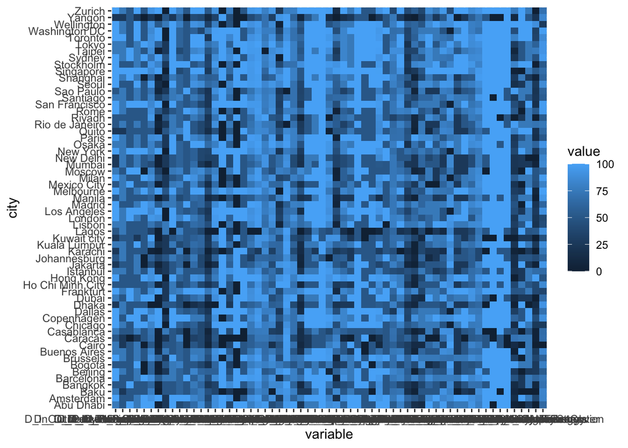

```r
library(ggplot2)
base = ggplot(data = safeL,
              aes(x = variable,
                  y =city))

heat1= base +  geom_tile(aes(fill = value))
heat1
```

Heatmap could be more informative if we reorder the axes. Let’s reorder rows (cities) and rows (indicators) by the median:

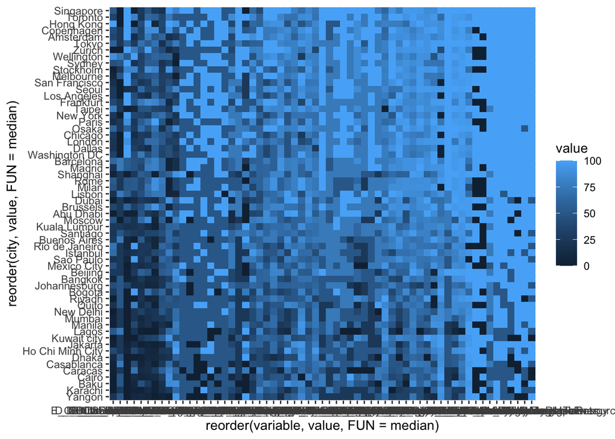

```r
base= ggplot(data = safeL)
vars_heat=base + aes(x = reorder(variable, value, FUN=median),
                               y =reorder(city,value, FUN=median))
geoms_heat= vars_heat + geom_tile(aes(fill = value))

geoms_heat
```

Here you can see what rows have higher or lower colors on what set of variables. You can customize color with a gradient:

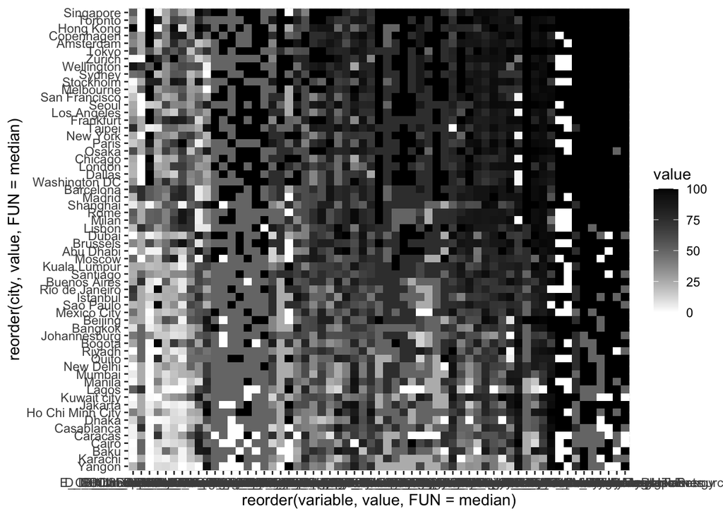

```r
#inverse color -1
geoms_heat = geoms_heat +
                scale_fill_gradient(low = "white",
                                    high = 'black'
                                    )
geoms_heat
```

The column names need some work:

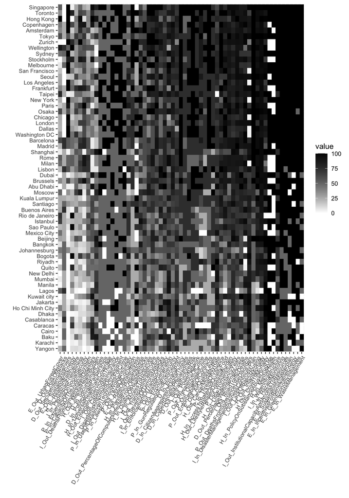

```r
geoms_heat +
  labs(x="", y="") +
    theme(axis.text.x = element_text(angle = 60,
                                         hjust = 1,
                                         size = 8),
                      axis.text.y = element_text(
                                         size = 8))
```

For sure, it would be a good idea to rename the column names. Notice the heatplot is a good idea to detect, in this case, particular city clusters, to know if what cities are doing very good, or very bad.

Would some data wrangling help the previous plot?

```r
safeL$type=ifelse(grepl("_In_",safeL$variable),'input','output')

safeL$variable=sub("_In_|_Out_",'_',safeL$variable)

# now we have:
head(safeL)
```

```
##        city        variable value  type
## 1 Abu Dhabi D_PrivacyPolicy    75 input
## 2 Amsterdam D_PrivacyPolicy   100 input
## 3      Baku D_PrivacyPolicy    75 input
## 4   Bangkok D_PrivacyPolicy    50 input
## 5 Barcelona D_PrivacyPolicy   100 input
## 6   Beijing D_PrivacyPolicy   100 input
```

Let’s use this:

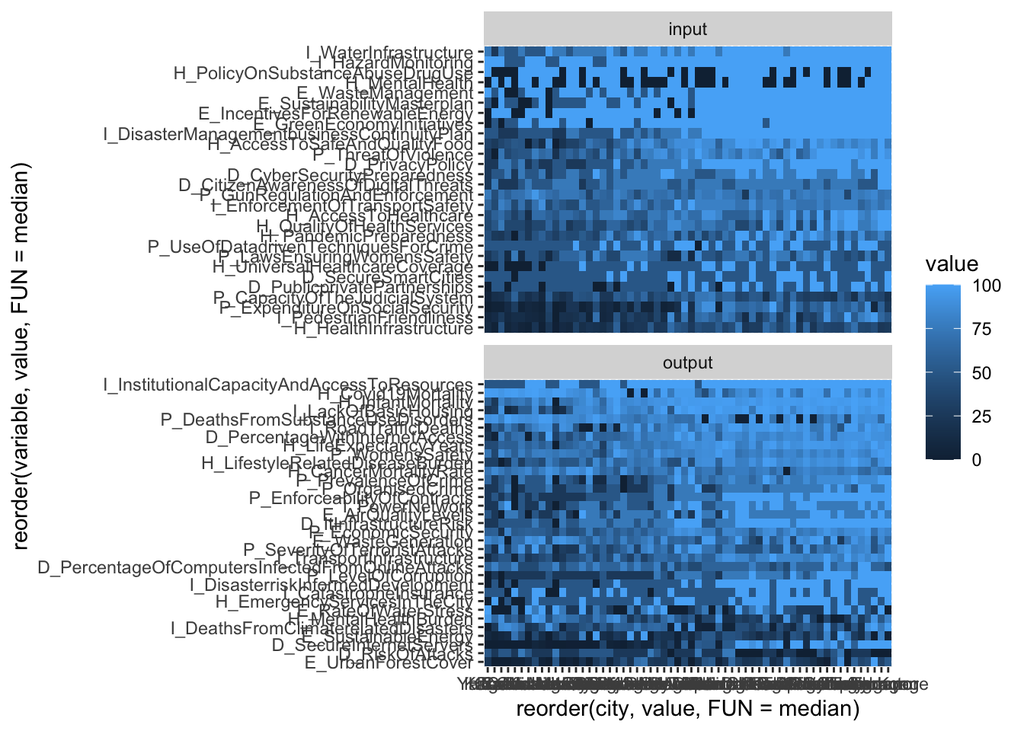

```r
base= ggplot(data = safeL)
vars_heat=base + aes(y = reorder(variable, value, FUN=median),
                               x =reorder(city, value, FUN=median))
geoms_heat= vars_heat + geom_tile(aes(fill = value))

geoms_heat_fct=geoms_heat + facet_wrap(~type, scales = "free_y", ncol = 1)
geoms_heat_fct
```

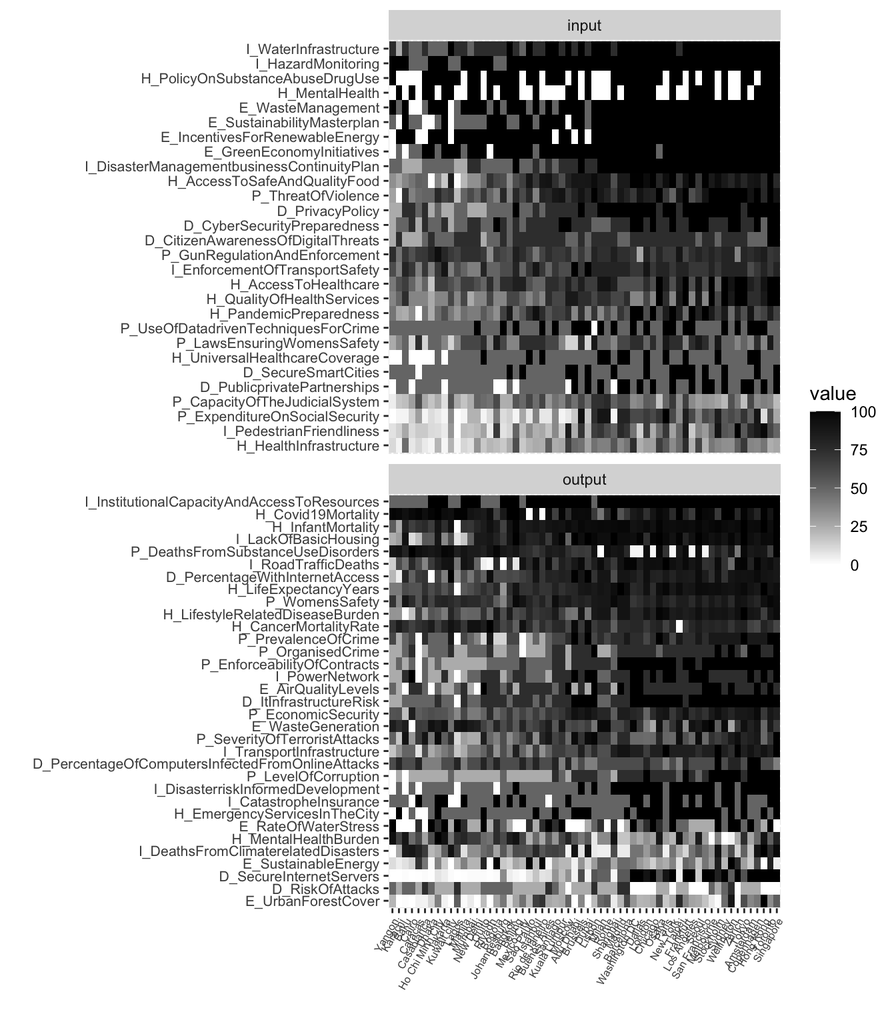

```r
geoms_heat_fct +
  labs(x="", y="") +
    theme(axis.text.x = element_text(angle = 60,
                                         hjust = 1,
                                         size = 6),
                      axis.text.y = element_text(
                                         size = 8))  +
      scale_fill_gradient(low = "white",
                          high = 'black')
```

more wrangling?

```r
safeL$dimension=substr(safeL$variable, 1, 1)
safeL$variable=gsub("^[A-Z]_", "", safeL$variable)

#then
safeL|>head()
```

```
##        city      variable value  type dimension
## 1 Abu Dhabi PrivacyPolicy    75 input         D
## 2 Amsterdam PrivacyPolicy   100 input         D
## 3      Baku PrivacyPolicy    75 input         D
## 4   Bangkok PrivacyPolicy    50 input         D
## 5 Barcelona PrivacyPolicy   100 input         D
## 6   Beijing PrivacyPolicy   100 input         D
```

Now take a look:

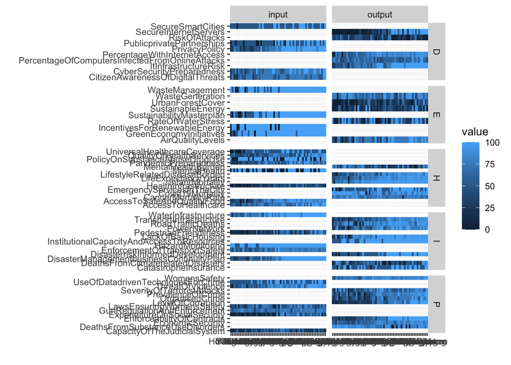

```r
base= ggplot(data = safeL)
vars_heat=base + aes(y = variable,
                     x =reorder(city, value, FUN=median))
geoms_heat= vars_heat + geom_tile(aes(fill = value))

geoms_heat_fct=geoms_heat + facet_grid(dimension~type, scales = "free_y")
geoms_heat_fct + labs(x="", y="")
```

This is not working well!

Unless the city and variable names are clearly seen, this may not be a good alternative. It may when we have fewer cities and variables, which comes next.

Go to table of contents.

# Averaging

This is still hard to read. An alternative could be to average by dimension:

```r
# Average by city and dimension
safe_avg = aggregate(value ~ city + type + dimension,
                            data = safeL,
                            FUN = mean,
                            na.rm = TRUE)

# Check the result
head(safe_avg)
```

```
##        city  type dimension value
## 1 Abu Dhabi input         D    80
## 2 Amsterdam input         D    75
## 3      Baku input         D    50
## 4   Bangkok input         D    60
## 5 Barcelona input         D    75
## 6   Beijing input         D    60
```

We may turn dimension into a factor to rename the levels easily.

```r
newLevels=c('DIGI','ENVIR','HEALTH','INFRA','PERS')
safe_avg$dimension=factor(safe_avg$dimension,
                          levels = c("D","E","H","I","P"),
                          labels = newLevels,ordered = F)
```

Let’s redo our heat map for the ‘input’ type:

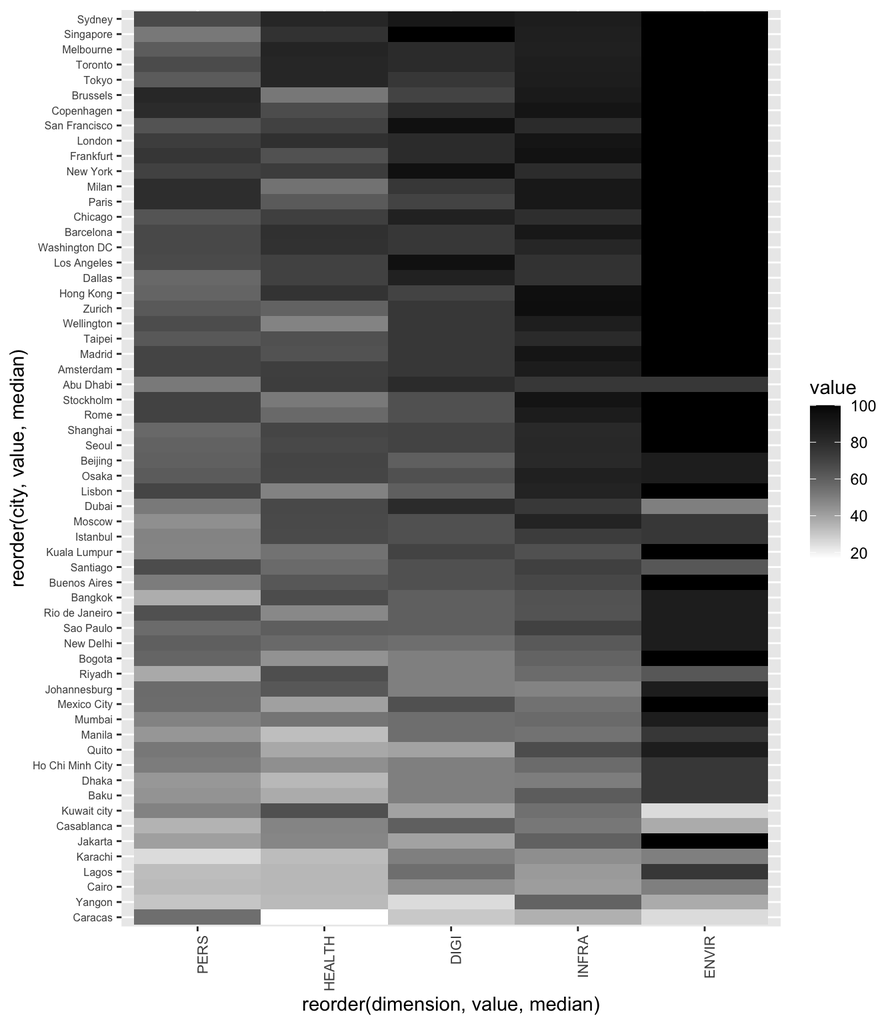

```r
base_ave_in= ggplot(data = safe_avg[safe_avg$type=='input',])

vars_ave_in=base_ave_in + aes(x = reorder(dimension,
                                          value,median),
                              y =reorder(city,
                                         value,
                                         median))

geoms_ave_in=vars_ave_in + geom_tile(aes(fill = value))

geoms_ave_in +
       scale_fill_gradient(low = 'white',
                           high = "black") +
       theme(axis.text.x = element_text(angle = 90,
                                        hjust = 1,
                                        size = 8),
             axis.text.y = element_text(size = 6))
```

With the current long format, making a faceted heatplot may work better as last time:

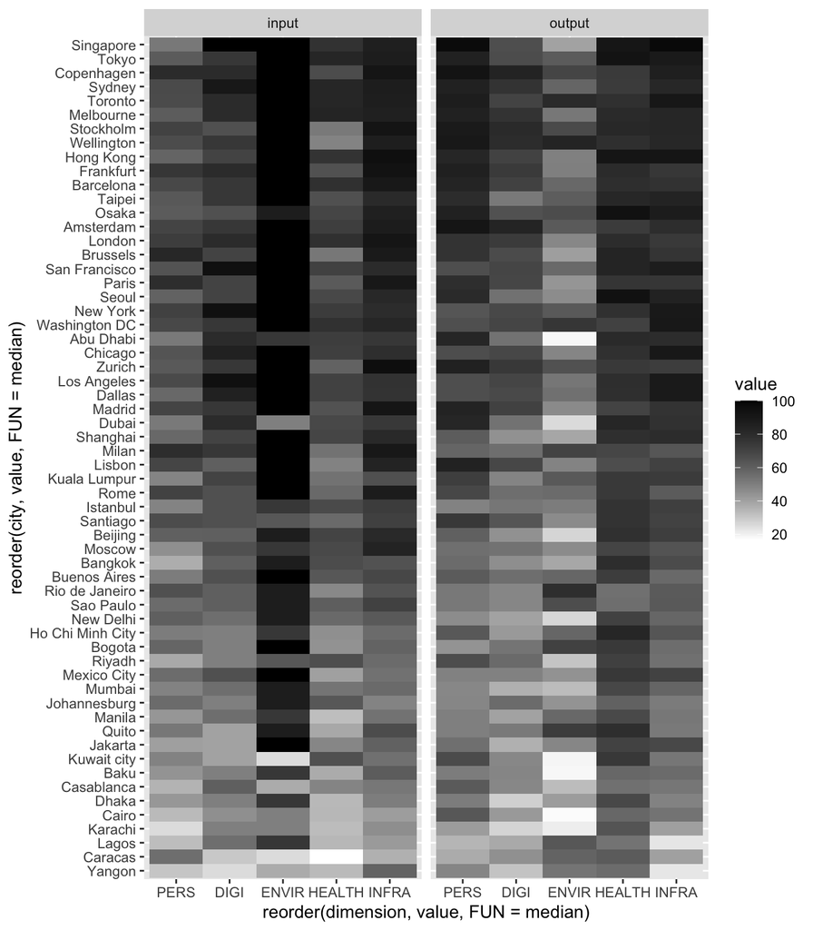

```r
base_ave= ggplot(data = safe_avg)

vars_ave=base_ave + aes(x = reorder(dimension,
                                          value,FUN=median),
                              y =reorder(city,
                                         value,
                                         FUN=median)) +
  facet_grid(~type,scales='free_x')

geoms_ave=vars_ave + geom_tile(aes(fill = value))

geoms_ave +
       scale_fill_gradient(low = 'white',
                           high = "black")
```

It did not!

We should compute a different plot for each *type*:

```r
# different data frames
safe_avg_out=safe_avg[safe_avg$type=='output',]
safe_avg_in=safe_avg[safe_avg$type=='input',]
```

Then, we use each type:

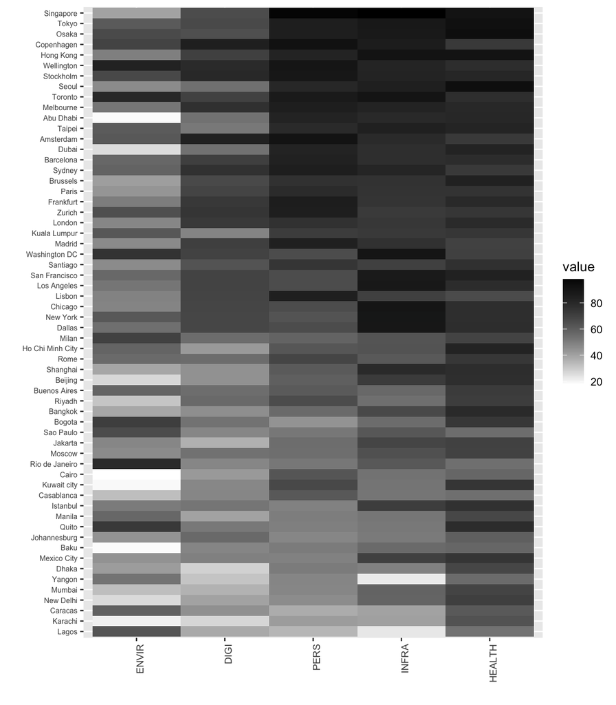

```r
base_ave_out= ggplot(data = safe_avg_out)

vars_ave_out=base_ave_out + aes(x = reorder(dimension,
                                          value,median),
                              y =reorder(city,
                                         value,
                                         median))

geoms_ave_out=vars_ave_out + geom_tile(aes(fill = value))

geoms_ave_out +
       scale_fill_gradient(low = 'white',
                           high = "black") +
       theme(axis.text.x = element_text(angle = 90,
                                        hjust = 1,
                                        size = 8),
             axis.text.y = element_text(size = 6)) + labs(x="",y='')
```

As you see, the cities have different locations according to type, which could not be captured when using facets.

## The Radar

When you have this limited amount of variables, the radar plot is an alternative:

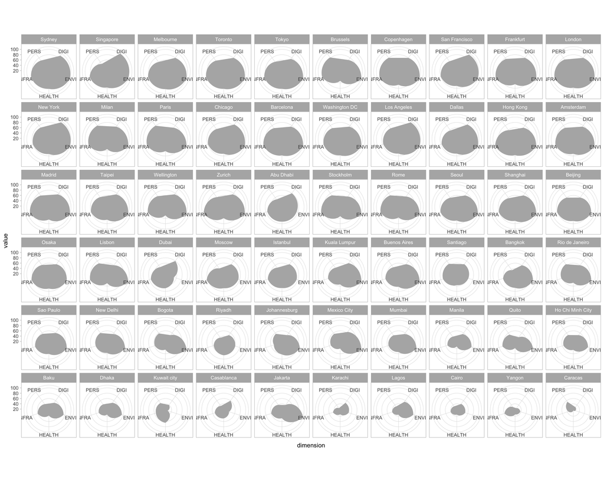

```r
library(ggforce)

base_rd  = ggplot(safe_avg_in) + theme_light()

vars_rd= base_rd + aes(x = dimension,
                   y = value)
geoms_rd=vars_rd + geom_shape(aes(group = city),fill = 'grey70') + coord_polar()


radar1_re = geoms_rd + facet_wrap(~reorder(city,-value, median),ncol = 10)

radar1_re
```

You could add extra customization. Let me change some defaults that help you later make improvements:

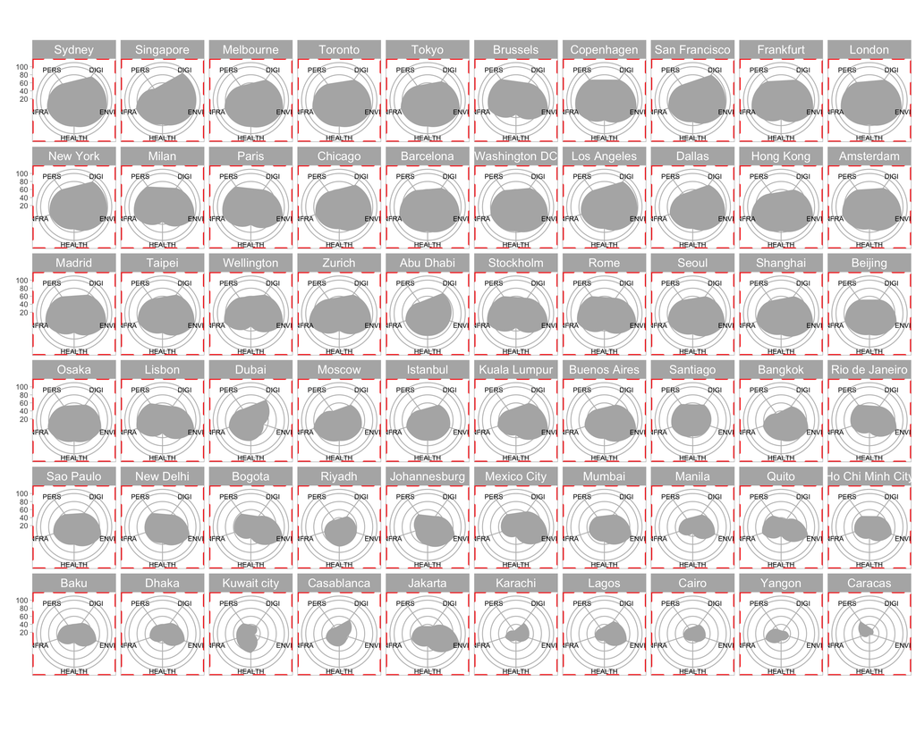

```r
radar1_re +
            theme(axis.text.x = element_text(size = 8, color='black'),
                  strip.text = element_text(size = 14),
                  panel.background=element_rect(fill = "white",
                         colour = "red",
                         linewidth = 1.5,
                         linetype = "dashed"),
                  panel.grid.major=element_line(linewidth = 0.5,
                      linetype = 'solid',
                      colour = "grey")
                  ) + labs(x='', y='')
```

The colors above **are not** the best choice, I just used them for you to notice where to make changes. Keep in mind that **areas are difficult to compare**, so the plots above might be used with care.

## Simplifying the Radar

The idea behind the radar plot can be represented by simpler plots:

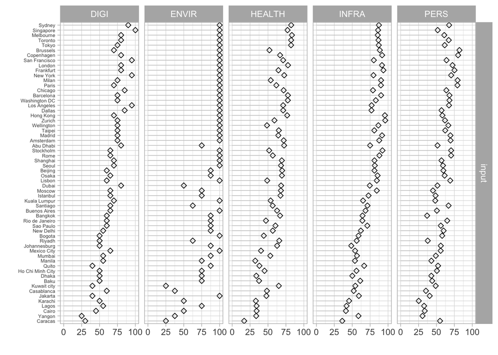

```r
vars_lolli=base_rd + aes(x=reorder(city, value,median),
                         y=value)
geoms_lolli=vars_lolli+ geom_point(shape=5)+ geom_segment(aes(x=city,
                                                  y=0,
                                                  yend = value,
                                                  xend = city),
                                              color='grey',linewidth=0.2)
geoms_lolli+ facet_grid(type~dimension) + coord_flip() +
    theme(axis.text.y = element_text(size = 5)) + labs(x='', y='')
```

> Averaging treats all variables equally, but what if some indicators are more informative than others? Dimensionality reduction techniques like EFA and MDS weight variables by their contribution to underlying patterns, potentially revealing structures that simple averaging obscures

Go to table of contents.

# Dimensionality Reduction

Plotting multivariate cases when three variables are present can be easily solved with facets, or adding an extra channel (i.e. *color*) to a bivariate plot. The cases above were very extreme, and they have served to reflect on the need to simplify that complexity.

We use the concept *dimensionality reduction* for these cases. The approach is similar to *averaging* in that it will summarize the variables into a much smaller set of variables; but differs drastically from *averaging* as the techniques will keep the relevant variables and may discard the variables not contributing to summary.

The techniques themselves are beyond this course; nevertheless, I will show you how they can be used and combined for our purposes.

Let’s work with all the **IN**put indicators:

```r
allIN=safe[,c(grep("_In_", names(safe) ))]
names(allIN)
```

```
##  [1] "D_In_PrivacyPolicy"
##  [2] "D_In_CitizenAwarenessOfDigitalThreats"
##  [3] "D_In_SecureSmartCities"
##  [4] "D_In_CyberSecurityPreparedness"
##  [5] "D_In_PublicprivatePartnerships"
##  [6] "H_In_UniversalHealthcareCoverage"
##  [7] "H_In_AccessToHealthcare"
##  [8] "H_In_QualityOfHealthServices"
##  [9] "H_In_HealthInfrastructure"
## [10] "H_In_AccessToSafeAndQualityFood"
## [11] "H_In_PolicyOnSubstanceAbuseDrugUse"
## [12] "H_In_PandemicPreparedness"
## [13] "H_In_MentalHealth"
## [14] "I_In_EnforcementOfTransportSafety"
## [15] "I_In_PedestrianFriendliness"
## [16] "I_In_DisasterManagementbusinessContinuityPlan"
## [17] "I_In_WaterInfrastructure"
## [18] "I_In_HazardMonitoring"
## [19] "P_In_UseOfDatadrivenTechniquesForCrime"
## [20] "P_In_GunRegulationAndEnforcement"
## [21] "P_In_ThreatOfViolence"
## [22] "P_In_CapacityOfTheJudicialSystem"
## [23] "P_In_ExpenditureOnSocialSecurity"
## [24] "P_In_LawsEnsuringWomensSafety"
## [25] "E_In_SustainabilityMasterplan"
## [26] "E_In_IncentivesForRenewableEnergy"
## [27] "E_In_GreenEconomyInitiatives"
## [28] "E_In_WasteManagement"
```

Preserve the city names at the index:

```r
rownames(allIN)=safe$city

##
head(allIN)
```

```
##           D_In_PrivacyPolicy D_In_CitizenAwarenessOfDigitalThreats
## Abu Dhabi                 75                                    50
## Amsterdam                100                                    50
## Baku                      75                                    25
## Bangkok                   50                                    50
## Barcelona                100                                    50
## Beijing                  100                                    75
##           D_In_SecureSmartCities D_In_CyberSecurityPreparedness
## Abu Dhabi                    100                             75
## Amsterdam                     50                             75
## Baku                          50                             50
## Bangkok                      100                             50
## Barcelona                     50                             75
## Beijing                       50                             75
##           D_In_PublicprivatePartnerships H_In_UniversalHealthcareCoverage
## Abu Dhabi                            100                               50
## Amsterdam                            100                              100
## Baku                                  50                               50
## Bangkok                               50                               50
## Barcelona                            100                              100
## Beijing                                0                               50
##           H_In_AccessToHealthcare H_In_QualityOfHealthServices
## Abu Dhabi                    66.7                         87.5
## Amsterdam                    83.3                         75.0
## Baku                         66.7                         75.0
## Bangkok                      75.0                         62.5
## Barcelona                    58.3                         75.0
## Beijing                      83.3                         62.5
##           H_In_HealthInfrastructure H_In_AccessToSafeAndQualityFood
## Abu Dhabi                      48.5                            89.4
## Amsterdam                      37.7                            89.2
## Baku                           46.5                            37.3
## Bangkok                        24.4                            34.7
## Barcelona                      43.7                            86.9
## Beijing                        59.0                            59.0
##           H_In_PolicyOnSubstanceAbuseDrugUse H_In_PandemicPreparedness
## Abu Dhabi                                100                      37.3
## Amsterdam                                100                      89.6
## Baku                                       0                      24.1
## Bangkok                                  100                      87.7
```

[output cut: 57 more lines]

```
## Beijing                            37.5                            50
##           E_In_IncentivesForRenewableEnergy E_In_GreenEconomyInitiatives
## Abu Dhabi                                 0                          100
## Amsterdam                               100                          100
## Baku                                    100                            0
## Bangkok                                 100                          100
## Barcelona                               100                          100
## Beijing                                 100                          100
##           E_In_WasteManagement
## Abu Dhabi                  100
## Amsterdam                  100
## Baku                       100
## Bangkok                    100
## Barcelona                  100
## Beijing                    100
```

With this data frame we will use the next techniques.

## Plotting with Factor Analysis (EFA)

When we averaged by dimension as we did before for the *radar plot*, we assumed all the indicators weight the same. We can use Exploratory Factor Analysis (EFA) to uncover the weight of the dimensions, but also to validate what dimensions exist, and what variables really bring information in the study.

### Previous steps…

EFA uses the correlation matrix (CM) as input. Once we have it, we can compute the KMO to assess the suitability if the variables to the multivariate process:

```r
#### notice you may need to install 'polycor' and 'psych'
## compute CM
CM=polycor::hetcor(allIN)$correlations # 'hetcor' in case you have numerical and categorical

##CM is suitable
KMO_tested=psych::KMO(CM)
##KMO measures how much the variables share common variance
##low values mean a variable is mostly noise
KMO_tested$MSA
```

```
## [1] 0.7042502
```

The value above 0.6 seems acceptable, but we still should drop the variables that individually bring noise to the analysis:

```r
# only the variables with a proper MSAi will remain
keep_vars = KMO_tested$MSAi >= 0.5
allIN_kmo_ok = allIN[, keep_vars]
ncol(allIN_kmo_ok)
```

```
## [1] 23
```

With this number of variables, we can determine the appropriate number of dimensions:

```r
## Detect the dimensions
CM_kmo_ok=polycor::hetcor(allIN_kmo_ok)$correlations
psych::fa.parallel(CM_kmo_ok, fm = "pa", fa = "fa",plot = F,n.obs = nrow(allIN_kmo_ok))
```

```
## Parallel analysis suggests that the number of factors =  3  and the number of components =  NA
```

We know that the set of var **THREE** dimension will get the best of the remaining informative variables, so we compute the EFA:

```r
#4. Compute the new dimensions
res_fa = psych::fa(CM_kmo_ok, n.obs = nrow(allIN_kmo_ok),
                    nfactors = 3, rotate = "varimax", fm = "pa")
```

From the **res_fa** object we can first determine how dimensions may be named, for that you read the **factor loadings**:

```r
print(res_fa$loadings)
```

```
##
## Loadings:
##                                               PA1    PA2    PA3
## D_In_PrivacyPolicy                             0.575  0.457  0.406
## D_In_SecureSmartCities                                0.272  0.327
## D_In_CyberSecurityPreparedness                 0.297  0.109  0.548
## D_In_PublicprivatePartnerships                 0.311  0.129  0.320
## H_In_UniversalHealthcareCoverage               0.637  0.191  0.179
## H_In_AccessToHealthcare                        0.165  0.769  0.242
## H_In_QualityOfHealthServices                   0.163  0.915  0.102
## H_In_HealthInfrastructure                      0.370  0.617  0.247
## H_In_AccessToSafeAndQualityFood                0.781  0.278  0.313
## H_In_PandemicPreparedness                      0.370         0.692
## I_In_EnforcementOfTransportSafety              0.236  0.461  0.304
## I_In_PedestrianFriendliness                    0.597  0.532  0.102
## I_In_DisasterManagementbusinessContinuityPlan  0.516  0.448  0.586
## I_In_WaterInfrastructure                       0.645  0.364  0.341
## I_In_HazardMonitoring                                 0.301  0.605
## P_In_UseOfDatadrivenTechniquesForCrime         0.253  0.233
## P_In_ThreatOfViolence                          0.511  0.490  0.337
## P_In_CapacityOfTheJudicialSystem               0.690        -0.166
## P_In_ExpenditureOnSocialSecurity               0.711  0.195  0.280
## P_In_LawsEnsuringWomensSafety                  0.397 -0.350  0.399
## E_In_SustainabilityMasterplan                  0.463  0.235  0.460
## E_In_GreenEconomyInitiatives                   0.438         0.254
## E_In_WasteManagement                                  0.273  0.701
##
##                  PA1   PA2   PA3
## SS loadings    4.826 3.745 3.498
## Proportion Var 0.210 0.163 0.152
## Cumulative Var 0.210 0.373 0.525
```

Each of the three summarizing factors have a higher or lower affinity to a particular variable (based on the values seen above). We can arguably propose this:

## Factor Summary Table

| Factor | Proposed Name | Key Indicators (Loadings ≥ 0.50) | Conceptual Definition |
| --- | --- | --- | --- |
| **PA1** | Foundational Public Services & Social Governance | • Access to Safe & Quality Food (0.781) • Expenditure on Social Security (0.711) • Capacity of Judicial System (0.690) • Water Infrastructure (0.645) • Universal Healthcare Coverage (0.637) • Pedestri… | Baseline institutional capacity to deliver essential welfare services, basic infrastructure, and core governance functions that support everyday quality of life. |
| **PA2** | Healthcare System Performance | • Quality of Health Services (0.915) • Access to Healthcare (0.769) • Health Infrastructure (0.617) | Effectiveness and accessibility of clinical care delivery, reflecting the operational performance of the health system distinct from policy commitments. |
| **PA3** | Crisis Preparedness & Environmental Resilience | • Waste Management (0.701) • Pandemic Preparedness (0.692) • Hazard Monitoring (0.605) • Disaster Management & Business Continuity (0.586) • Cybersecurity Preparedness (0.548) | Forward-looking systemic capacities to anticipate, absorb, and recover from acute shocks and chronic stresses across environmental, health, and digital domains. |

Given we have ‘names’ for the factors, we can pay attention to the value values of the variables for each city. For that, we retrieve the scores:

```r
city_scores = psych::factor.scores(allIN_kmo_ok, res_fa)$scores|>as.data.frame()
head(city_scores)
```

```
##                  PA1          PA2         PA3
## Abu Dhabi -0.6212441  1.613918504 -0.25008185
## Amsterdam  0.8407107  0.613669018  0.26875350
## Baku      -1.4279912  0.680353826 -0.61414836
## Bangkok   -1.4328007 -0.004966097  0.50018787
## Barcelona  1.1557453  0.339684602 -0.09436839
## Beijing   -0.3154125  0.944777644 -0.09317526
```

These scores are standardized values that we can normalize (0-100) for easier reading of the plots:

```r
# normalizing
library(BBmisc)
efa_scores_norm=normalize(city_scores,
                       method = "range",
                       margin=2, # by column
                       range = c(0, 100))

# new  vars

city_scores$governance=efa_scores_norm[,1]
city_scores$health_system=efa_scores_norm[,2]
city_scores$preparedness=efa_scores_norm[,3]

city_scores[,4:6]
```

```
##                  governance health_system preparedness
## Abu Dhabi         41.610248     92.906058    58.809451
## Amsterdam         80.892407     63.561609    69.127989
## Baku              19.933264     65.517950    51.568938
## Bangkok           19.804033     45.412631    73.730729
## Barcelona         89.357264     55.523693    61.906262
## Beijing           49.827823     73.275386    61.929991
## Bogota            82.411067      5.475372    42.271724
## Brussels          86.399667     58.015438    65.315204
## Buenos Aires      55.856284     57.955496    69.019778
## Cairo             42.000702     25.650356    20.353773
## Caracas           71.285483     10.099966     0.000000
## Casablanca        44.415435     23.468621    39.156547
## Chicago           82.369020      2.892330    92.807973
## Copenhagen        88.520541     56.207623    69.384386
## Dallas            76.772521      3.561997    98.185006
## Dhaka              6.183084      9.513986    62.273736
## Dubai             53.339221     73.159045    46.034388
## Frankfurt         86.150893    100.000000    49.020924
## Ho Chi Minh City  23.485781     23.455961    69.059466
## Hong Kong         63.369503     80.227686    61.311195
## Istanbul          43.992170     28.755304    81.702355
## Jakarta            0.000000     26.257715    80.296178
## Johannesburg      53.944471     21.581100    55.910163
## Karachi            4.079526     33.130963    42.187726
## Kuala Lumpur      33.063336     54.754117    79.012601
## Kuwait city       85.139755     44.198070     2.393244
## Lagos             28.681988     20.717291    35.022534
## Lisbon            96.609309     27.958061    58.262587
## London            89.365762     52.451762    67.214371
## Los Angeles       71.724060      7.685633    98.900269
## Madrid            94.308050     38.685871    67.221667
## Manila            14.870808     41.914146    58.248944
## Melbourne         53.666116     84.848551    78.570100
## Mexico City       47.625656     24.786249    65.951982
## Milan            100.000000     63.141377    47.563352
## Moscow            54.058895     83.477570    50.288421
## Mumbai            33.717111      0.000000    74.119349
## New Delhi         39.593906     21.745703    63.919532
## New York          82.363509      8.657226    89.158398
## Osaka             46.116253     89.840449    71.098999
## Paris             91.710783     54.715282    69.990578
## Quito             51.031753     15.090604    62.956407
## Rio de Janeiro    80.171836     14.097050    55.896238
## Riyadh            42.397402     45.527732    46.505680
## Rome              93.876962     63.392933    55.454692
## San Francisco     76.195251      1.616600   100.000000
## Santiago          71.563805     39.366286    49.692283
## Sao Paulo         91.262703      1.927073    53.523898
## Seoul             47.725392     68.522370    84.831796
## Shanghai          45.861809     72.367316    68.770058
## Singapore         41.859793     84.811324    81.596250
## Stockholm         96.572395     35.472889    72.346529
## Sydney            48.898048     89.447239    82.389715
## Taipei            37.016082     76.804993    85.538875
## Tokyo             54.781567     82.584474    68.140572
## Toronto           67.593724     76.432562    79.003118
## Washington DC     82.287074     12.790437    88.064814
## Wellington        67.972938     76.622019    63.813113
## Yangon             4.412743     28.755835    65.702641
## Zurich            68.073146     92.685945    64.455507
```

After so much stats, we can produce a simple plot like a lollipop. Let’s turn those columns into a long shape, and plot:

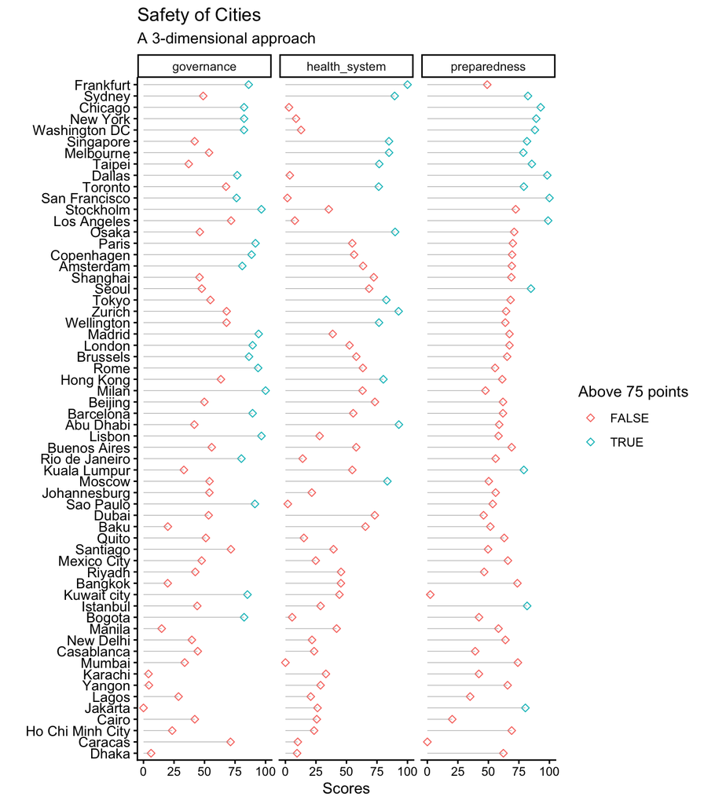

```r
##reshaping
city_scores_wide=city_scores[,4:6]
city_scores_wide$city=rownames(city_scores_wide)
city_scores_long=melt(city_scores_wide,id.vars = 'city')

##plotting
baseefa=ggplot(data=city_scores_long) + theme_classic()

varsefa=baseefa + aes(x=reorder(city, value,median),y=value)

geomsefa= varsefa + geom_point(shape=5, aes(color=value>75))+
                    geom_segment(aes(x=city,y=0,yend = value,xend = city),
                                 color='grey70',linewidth=0.2)
geomsefa +  facet_grid(~variable) + coord_flip() +
            theme(axis.text.y = element_text(size = 10)) +
            labs(title = "Safety of Cities",
                 subtitle = "A 3-dimensional approach",
                 x="", y='Scores', color="Above 75 points")
```

Of course, you may use a scatter plot:

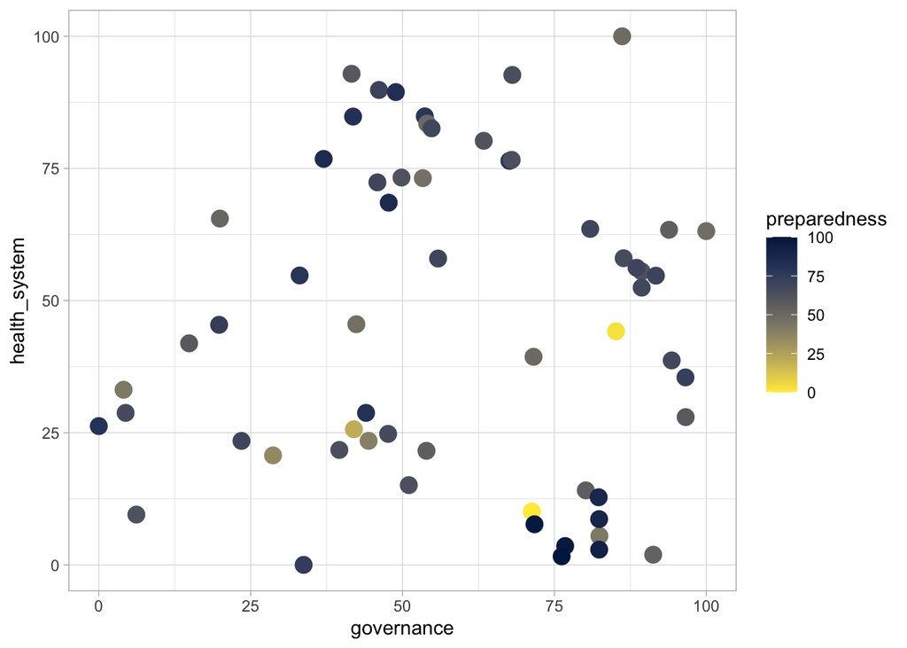

```r
base_efa_cor=ggplot(city_scores) + theme_light()
vars_efa_cor=base_efa_cor + aes(x=governance, y=health_system, color=preparedness)
geoms_efa_cor = vars_efa_cor + geom_point(size=4)
geoms_efa_cor + scale_color_viridis_c(direction = -1,option = 'cividis')
```

Alternatively,

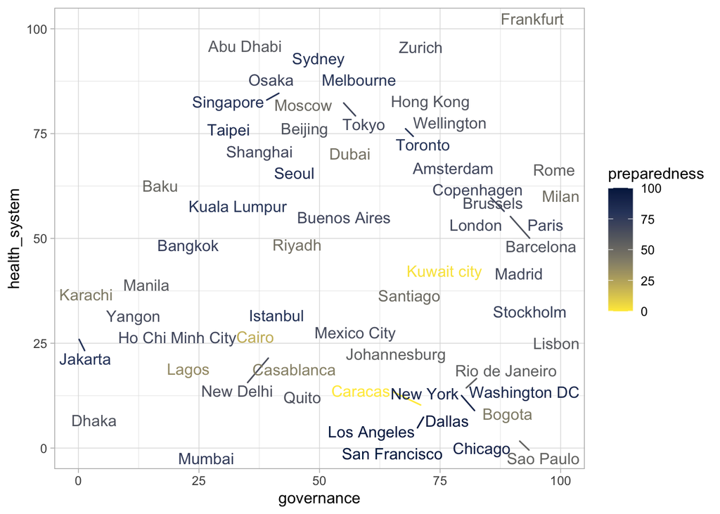

```r
# city names back to data
city_scores$namecity=row.names(city_scores)

library(ggrepel)

base_efa_cor=ggplot(city_scores) + theme_light()
vars_efa_cor=base_efa_cor + aes(x=governance, y=health_system)
geoms_efa_cor = vars_efa_cor + geom_text_repel(aes(color=preparedness, label=namecity),
                                               max.overlaps = 20)
geoms_efa_cor + scale_color_viridis_c(direction = -1,option = 'cividis')
```

## Plotting with MDS

You can use multidimensional scaling (MDS) to synthesize **all the variables in a two dimensional plot**. This will create a **map** that will allow you to visualize “neighborhoods of similarity” of the cases (cities).

MDS requires as input the **distance matrix** among cases, notice we will use the **city_scores_wide** data frame, which was built without the non-informative variables:

```r
library(cluster)
dist_in_safe=cluster::daisy(city_scores_wide[,c('governance','health_system','preparedness')],
                            metric = 'gower') # 'gower' in case you have numerical and categorical
```

> Notice we ran MDS on the 3 EFA dimensions (not 61 variables) to visualize how cities relate in the reduced factor space

Using the distances, we can try MDS and check the goodness of fit:

```r
theMap=cmdscale(dist_in_safe,k = 2,eig = T)
theMap$GOF[2]
```

```
## [1] 0.6241963
```

We are recovering around 62% of the information (thus losing the around 38%). While not terrible, we should try a **non-metric MDS** approach, which often fits complex social data better:

```r
theMap$GOF
```

```
## [1] 0.5083398 0.6241963
```

We can try an alternative technique:

```r
# you may need to install 'MASS' library
theMap_iso=MASS::isoMDS(dist_in_safe,k = 2)
theMap_iso$stress
```

```
## [1] 14.99771
```

The stress value of ~0.15 indicates an acceptable fit — better than the classical MDS result, though ideally stress should be below 0.10 for a reliable 2D representation.

### Stress Interpretation (Non-metric MDS)

| Stress Value | Quality | Interpretation |
| --- | --- | --- |
| < 0.05 | Excellent | Perfect representation |
| < 0.10 | Good | Reliable 2D map |
| < 0.20 | Acceptable | Suitable for exploration |
| > 0.20 | Poor | Consider more dimensions |

**Our result:** ~0.15 → **Acceptable for exploratory visualization** ✓

Let’s use this last result

```r
city_scores_wide$dim1=theMap_iso$points[,1]
city_scores_wide$dim2=theMap_iso$points[,2]
```

Using those values, see the map:

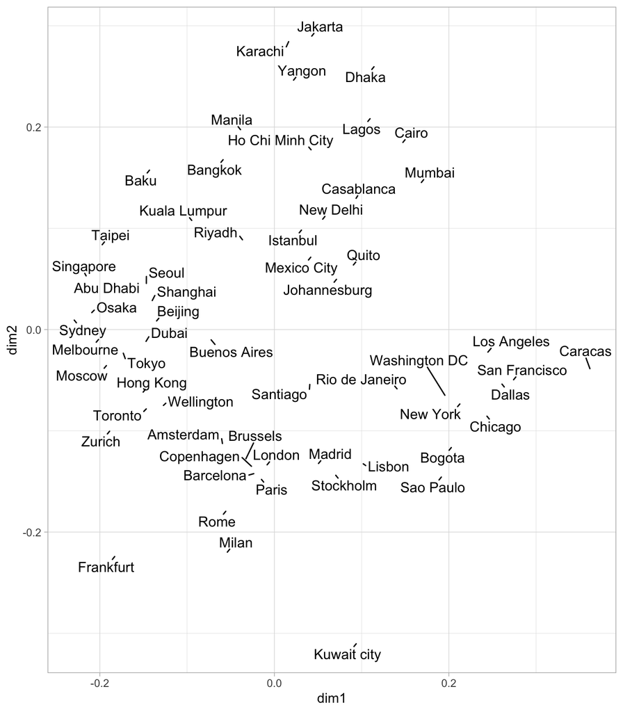

```r
city_scores_wide$city=row.names(city_scores_wide)
base_mds=ggplot(city_scores_wide) + theme_light()
vars_mds=base_mds + aes(x=dim1,y=dim2,label=city)
geoms_mds=vars_mds + geom_text_repel(size=4,min.segment.length = 0)

#
geoms_mds
```

## Plotting with Cluster info

**Clustering** comes in handy to improve the previous viz. Each city will be grouped by affinity (similarity). That grouping depends on the technique used.

Let’s compare the hierarchical clustering technique (HC), a technique that clusters every row (city).

### Using HC

HC requires you know how many clusters to detect. That analysis is beyond the session (and course). Let’s just *assume* we need 5 clusters:

```r
library(factoextra)

res.hc= hcut(dist_in_safe, k = 5)

## Add them to data frame
city_scores_wide$hc=as.factor(res.hc$cluster)
```

Let’s redo the previous plot:

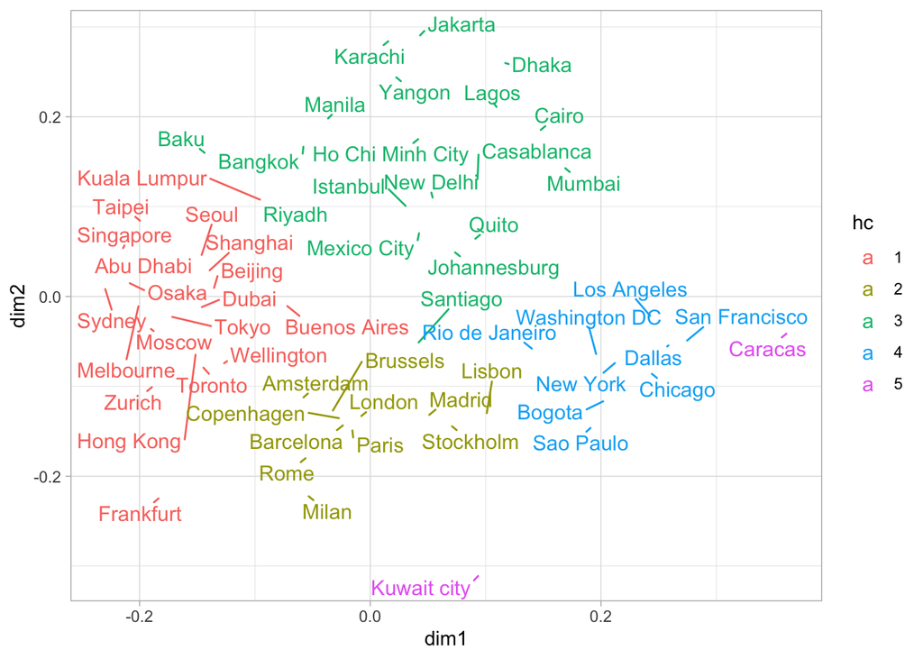

```r
base_mds_hc=ggplot(city_scores_wide) + theme_light()
vars_mds_hc=base_mds_hc + aes(x=dim1,y=dim2,label=city, color=hc)
geoms_mds_hc=vars_mds_hc + geom_text_repel(size=4,max.overlaps = 20, min.segment.length = 0)

#
geoms_mds_hc
```

Notice that the ideal viz will separate clearly the country groups, but that is not happening. In fact, it may be due to the nature of the HC technique, which will not inform about outliers; that being said, there are other clustering techniques (namely dbscan) that do show cases (countries) that do not belong to any cluster. Several other reason are explored in other courses.

# Method Comparison

| Method | Best For | Limitations |
| --- | --- | --- |
| **Comprehensive Heatmap** | Showing all data, detecting outliers | Overwhelming with >50 variables |
| **Averaging** | Simple summaries, policy dashboards | Assumes equal weights, loses detail |
| **EFA** | Uncovering latent structures, weighting variables | Requires statistical assumptions |
| **MDS** | Visualizing similarity/dissimilarity | Loses information (check GOF/stress) |
| **Clustering** | Grouping similar cases | Sensitive to distance metric, k choice |

Go to table of contents.